# Laboration 2

Andrew Dean & Ekaterina Kershinskaia

2026-10-09

# Sammanfattning

Den här labben handlar om att använda slumptalsgeneratorer för att simulera olika fördelningar för att få en bättre intution för hur olika fördelningar beter sig. Vi vill också undersöka likformigheten av R:s inbygdd slumptalsgenerator.

# Uppgift 1

## Teoretiska uppgifter

### Upggift 1.1

Vi delar intervallet $[0, 1]$ i $k$ like stora delintervall.

Det första intervallet ges alltså av $I_1 = [0, \frac{1}{k}]$.

Det sista intervallet ges av $I_k = [1 - \frac{1}{k}, 1]$.

### Upggift 1.2

Längden hos varje delintervall ges av $l = \frac{1}{k}$.

### Uppgift 1.3

Sannolikheten att ett slumptal generarad från $Likf[0,1]$ hamnar i $I_1$ är $\frac{1}{k}$.

Sannolikheten att ett slumptal generarad från $Likf[0,1]$ inte hamnar i $I_1$ är $1 - \frac{1}{k}$.

Sannolikheten att hamna i det första intervallet ges av en **Bernoullifördelning** med parametern $p = \frac{1}{k}$.

### Uppgift 1.4

Om vi genererar nu $n$ slumptal från $Likf[0,1]$, sannolikheten att $j$ av dessa hamnar i det första delintervallet ges av en **binomialfördelning** $X_1 \sim B(n, \frac{1}{k})$ eftersom alla genererade slumptal är oberoende och har densamma sannolikhet att hamna i $I_1$. Sannolikheten ges alltså av:

$P(X_1 = j) = \binom{n}{j} \cdot (\frac{1}{k})^j \cdot (1 - \frac{1}{k})^{n-j}$

### Uppgift 1.5

Ja, $X_1, X_2, X_3, ..., X_k$ har samma sannolikhetsfördelning som $X_1$. Det här är för att sannolikheten att hamna i ett godtyckligt detintervall är fortfarande $\frac{1}{k}$, eftersom alla delintervall är lika stora.

$X_1, X_2, X_3, ..., X_k$ är ej obereonde av varandra. Till exempel, om $X_1 = n$, då medför det att $X_j = 0$ för alla andra $j \neq 1$, eftersom det finns inga slumptal kvar att hamna i ett annat delintervall än $I_1$.

### Uppgift 1.6

Vi sätter $Y_1 := \frac{X_1}{n}$, dvs. andelen av observationerna som hamnar i $I_1$.

$\mathbb{E}[X_1] = np = n \cdot \frac{1}{k} = \frac{n}{k}$.

$\operatorname{Var}(X_1) = np(1-p) = \frac{n}{k}(1 - \frac{1}{k})$.

$\mathbb{E}[Y_1] = \mathbb{E}[\frac{X_1}{n}] = \frac{1}{n}\mathbb{E}[X_1] = \frac{1}{n} \cdot \frac{n}{k} = \frac{1}{k}$.

$\operatorname{Var}(Y_1) = \operatorname{Var}(X_1/n) = \frac{1}{n^2} \operatorname{Var}(X_1) = \frac{1}{n^2} \cdot \frac{n}{k}(1 - \frac{1}{k}) = \frac{1}{nk}(1 - \frac{1}{k})$.

$\operatorname{D}(Y_1) = \sqrt{Var(Y_1)} = \sqrt{\frac{1}{nk}(1 - \frac{1}{k})}$.

## Kodrelaterade uppgifter

```r
set.seed(19981207)


K = 10


calculate_attributes <- function(n) {
  E_X = n/K
  Var_X = (n/K)*(1 - 1/K)
  D_X = sqrt(Var_X)

  E_Y = E_X/n
  Var_Y = Var_X/(n^2)
  D_Y = sqrt(Var_Y)

  list(E_X = E_X, D_X = D_X, E_Y = E_Y, D_Y = D_Y)
}


antal_hist <- function(x, E_X, D_X) {
  hist(
    x,
    breaks = seq(from = 0, to = max(1, max(x)), length.out = K + 1),    # Skapar 10 delintervall
    main = "Histogram",
    ylab = "Antal",
    xlab = "Värde",
    ylim = c(0, E_X + 4*D_X)
  )
  abline(a = E_X, b = 0, col = "grey")
  abline(a = E_X + 3*D_X, b = 0, col = "red")
  abline(a = E_X - 3*D_X, b = 0, col = "red")
}


andel_hist <- function(x, E_Y, D_Y) {
  p <- hist(x, breaks = seq(from = 0, to = max(1, max(x)), length.out = K + 1), plot = FALSE)
  p$counts <- p$counts / sum(p$counts)    # Konvertera antal till andelar
  plot(p,
       main = "Andelshistogram",
       ylab = "Andel",
       xlab = "Värde",
       ylim = c(0, E_Y + 4*D_Y))
  axis(2)
  abline(a = E_Y, b = 0, col = "grey")
  abline(a = E_Y + 3*D_Y, b = 0, col = "red")
  abline(a = E_Y - 3*D_Y, b = 0, col = "red")
}
```

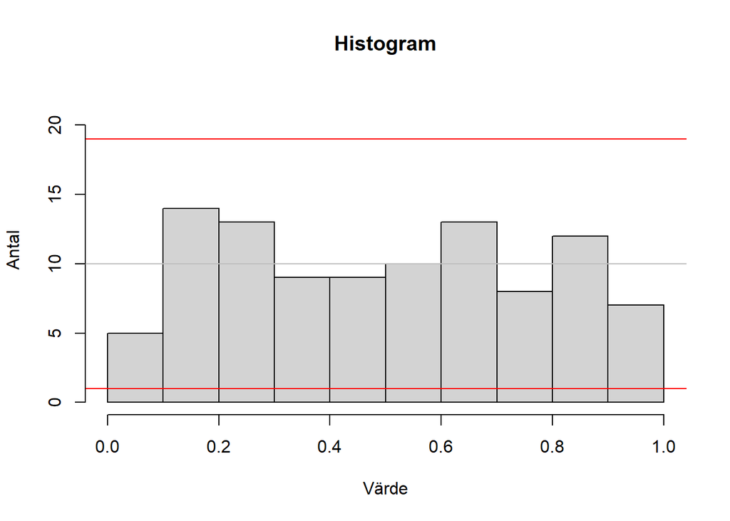

Figur 1: Antalet observationer per intervall (n=100)

```r
n <- 100

slumptal <- runif(n)
attributes = calculate_attributes(n)

antal_hist(slumptal, attributes$E_X, attributes$D_X)
```

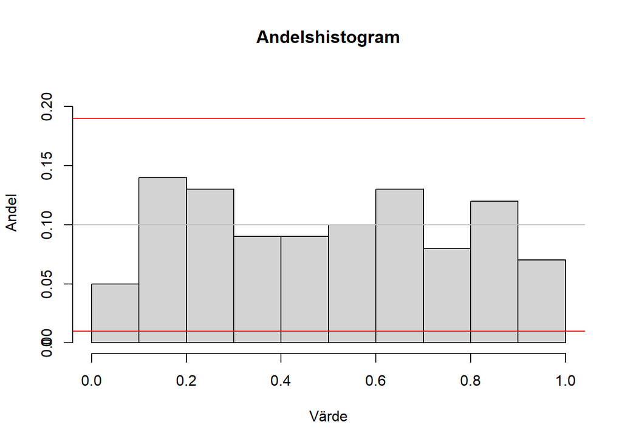

Figur 2: Andelen observationer per intervall (n=100)

```r
andel_hist(slumptal, attributes$E_Y, attributes$D_Y)
```

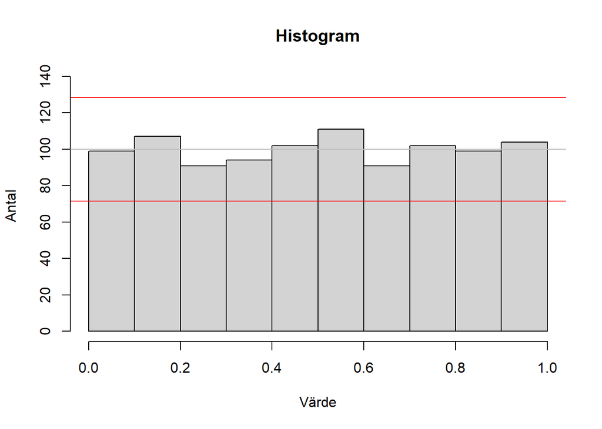

Figur 3: Antalet observationer per intervall (n=1000)

```r
n <- 1000

slumptal <- runif(n)
attributes = calculate_attributes(n)

antal_hist(slumptal, attributes$E_X, attributes$D_X)
```

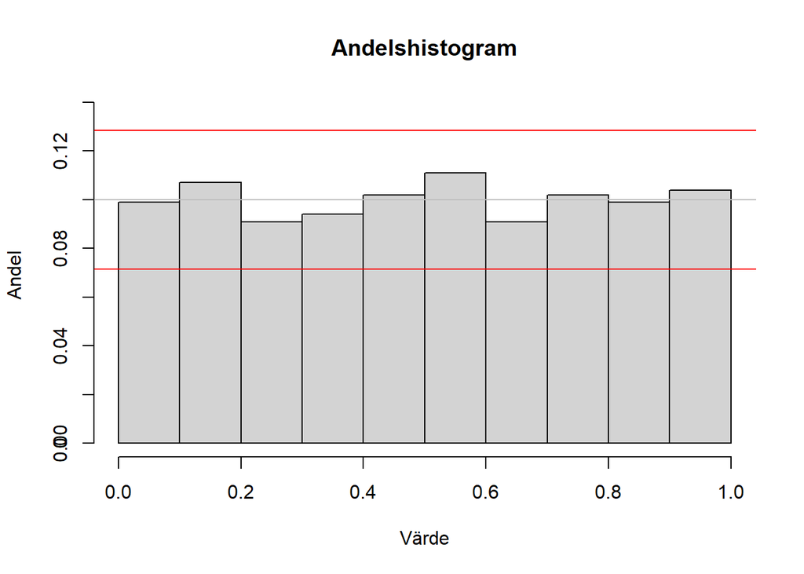

Figur 4: Andelen observationer per intervall (n=1000)

```r
andel_hist(slumptal, attributes$E_Y, attributes$D_Y)
```

1. I figur 2 ser vi andelen slumpmässigt generarade observationer som hamnar i varje delintervall. Det *ser* inte exakt ut som en likformig fördelning (som förväntas vara helt “platt”), särskilt i det första intervallet, men det här är på grund av det lilla urvalet av bara $n=100$ observationer.

   Det är dock väl inom 3 standardavvikelser av det som förväntas av en likformig fördelning med så få observationer (visat av de röda linjer på histogrammet), och därför kan vi inte dra slutsatsen att observationerna inte kom från en sådan fördelning.

   Se uppgifter 2 och 3 nedan för en djupare teoretisk förklaring.
2. För större $n$, som $n=1000$ (se figur 4), ser andelshistogrammet väldigt mycket “plattare” ut. Ännu större värden på $n$ ger en ännu “plattare” fördelning. Det här är förväntat eftersom standardavvikelse $\sigma \propto \frac{1}{\sqrt{n}}$.
3. Vi förväntar oss att andelen i var och en av de 10 klasserna ska vara $1/10 = 0.1$.

   I figur 2, där $n=100$, 3 standardavvikelser ges av:

   $3\sigma_{n=100} = 3\sqrt{\frac{1}{nk}(1 - \frac{1}{k})} = 3\sqrt{\frac{1}{100\cdot10}(1 - \frac{1}{10})} = 0.09$.

   Den största avvikelsen i figur 2 är $Y_1$, där felet är $|0.1-0.05|=0.05$, som är märkbart mindre än $3\sigma = 0.09$.

   I figur 4, där $n=1000$, 3 standardavvikelser ges av:

   $3\sigma_{n=1000} = 3\sqrt{\frac{1}{nk}(1 - \frac{1}{k})} = 3\sqrt{\frac{1}{1000\cdot10}(1 - \frac{1}{10})} \approx 0.028$.

# Uppgift 2

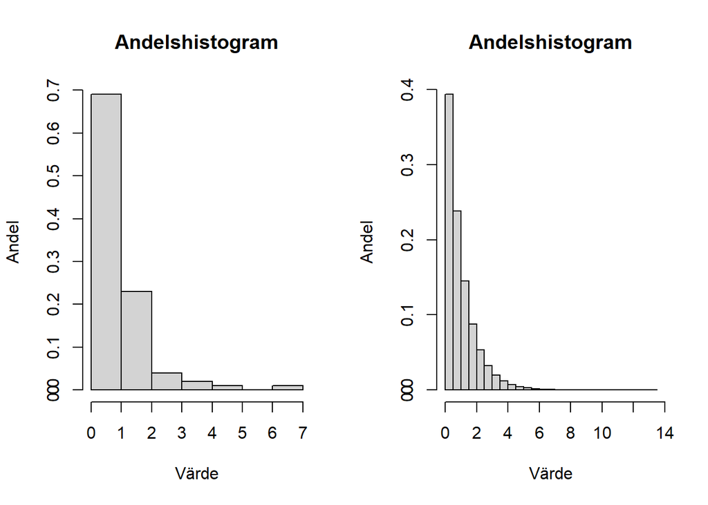

```r
prop_hist <- function(x, xlab = "Värde") {
  p <- hist(x, plot = FALSE)
  p$counts <- p$counts / sum(p$counts)    # Konvertera antal till andelar
  plot(p,
       main = "Andelshistogram",
       ylab = "Andel",
       xlab = xlab)
  axis(2)
}
n1 <- 100
n2 <- 1000000
a <- 1

par(mfrow = c(1,2))
prop_hist(rexp(n1, rate = a))
prop_hist(rexp(n2, rate = a))
```

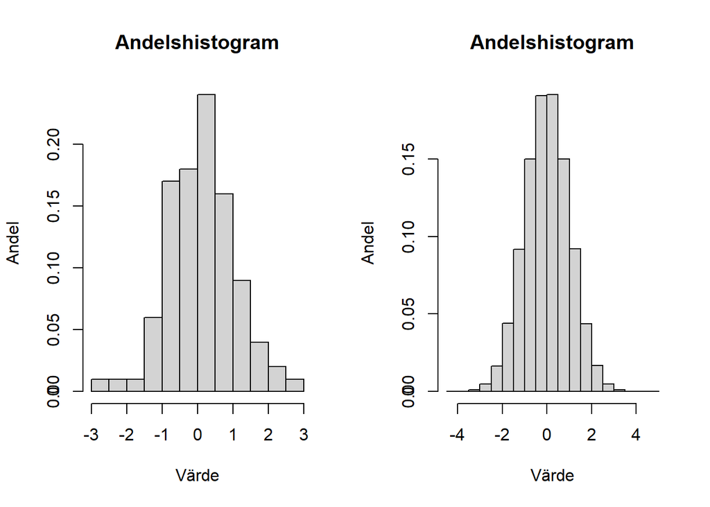

```r
m <- 0
s <- 1

par(mfrow = c(1,2))
prop_hist(rnorm(n1, mean = m, sd = s))
prop_hist(rnorm(n2, mean = m, sd = s))
```

# Uppgift 3

```r
n <- 100
k <- 10


E_X = n/k
Var_X = (n/k)*(1 - 1/k)
D_X = sqrt(Var_X)

E_Y = E_X/n
Var_Y = Var_X/(n^2)
D_Y = sqrt(Var_Y)


x <- rexp(n, rate = 2)
v <- 1 - exp(-2 * x)




prop_hist <- function(x, xlab = "Värde") {
  p <- hist(x, plot = FALSE)
  p$counts <- p$counts / sum(p$counts)    # Konvertera antal till andelar
  plot(p,
       main = "Andelshistogram",
       ylab = "Andel",
       xlab = xlab,
       ylim = c(0, 0.2))
  axis(2)
}

print(E_Y)
```

```
## [1] 0.1
```

```r
print(D_Y)
```

```
## [1] 0.03
```

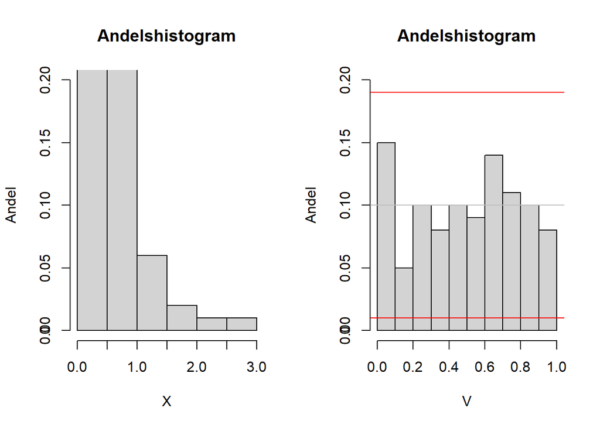

```r
# Plotta x och v bredvid varandra
par(mfrow = c(1, 2))
prop_hist(x, xlab = "X")
prop_hist(v, xlab = "V")


abline(a = E_Y, b = 0, col = "grey")
abline(a = E_Y + 3 * D_Y, b = 0, col = "red")
abline(a = E_Y - 3 * D_Y, b = 0, col = "red")
```